# Objects Launched into Space

Proposal

INFO526 Term Project

Author

Affiliation

Derek Rice

School of Information, University of Arizona

```r
if (!require("pacman"))
    install.packages("pacman")

pacman::p_load(tidyverse, tidytuesdayR, dplyr, janitor, lubridate,ggplot2)
```

## Dataset: Outer Space Objects

- The dataset summarizes the number of objects launched into space from 1957 to 2023 as a function of entity.
- The source of the dataset is the United Nations Office of Outer Space Affairs. A prior analysis of the dataset is available here: https://ourworldindata.org/grapher/yearly-number-of-objects-launched-into-outer-space
- Dataset source: https://github.com/rfordatascience/tidytuesday/blob/master/data/2024/2024-04-23/readme.md
- The dataset is comprised of 4 columns and 1175 rows - see “head” and “glimpse” summarized herein.
- I choose the dataset because I was thinking it would be interesting to identify the countries launching gadgets into space and the magnitude of the difference between the United States and other countries.
- A graphical plot summary of the data is provided below - the plot presents an overview of the dataset and visually displays the number of launches per entity between 1957 and 2023.

```r
# cite: https://github.com/rfordatascience/tidytuesday/blob/master/data/2024/2024-04-23/readme.md

outer_space_objects <- readr::read_csv('https://raw.githubusercontent.com/rfordatascience/tidytuesday/master/data/2024/2024-04-23/outer_space_objects.csv')
```

```r
dim(outer_space_objects)
```

```
[1] 1175    4
```

```r
head(outer_space_objects)
```

```
# A tibble: 6 × 4
  Entity  Code   Year num_objects
  <chr>   <chr> <dbl>       <dbl>
1 APSCO   <NA>   2023           1
2 Algeria DZA    2002           1
3 Algeria DZA    2010           1
4 Algeria DZA    2016           3
5 Algeria DZA    2017           1
6 Angola  AGO    2017           1
```

```r
glimpse(outer_space_objects)
```

```
Rows: 1,175
Columns: 4
$ Entity      <chr> "APSCO", "Algeria", "Algeria", "Algeria", "Algeria", "Ango…
$ Code        <chr> NA, "DZA", "DZA", "DZA", "DZA", "AGO", "AGO", NA, NA, NA, …
$ Year        <dbl> 2023, 2002, 2010, 2016, 2017, 2017, 2022, 1985, 1992, 1996…
$ num_objects <dbl> 1, 1, 1, 3, 1, 1, 1, 2, 1, 2, 1, 2, 1, 2, 1, 1, 1, 1, 1, 3…
```

```r
filtered_outer_space_objects = outer_space_objects %>%
  filter (Entity %in% c("United States","China","Russia","Japan","France","India","European Space Agency", "Germany"))
```

## Graphical Summary of the Dataset

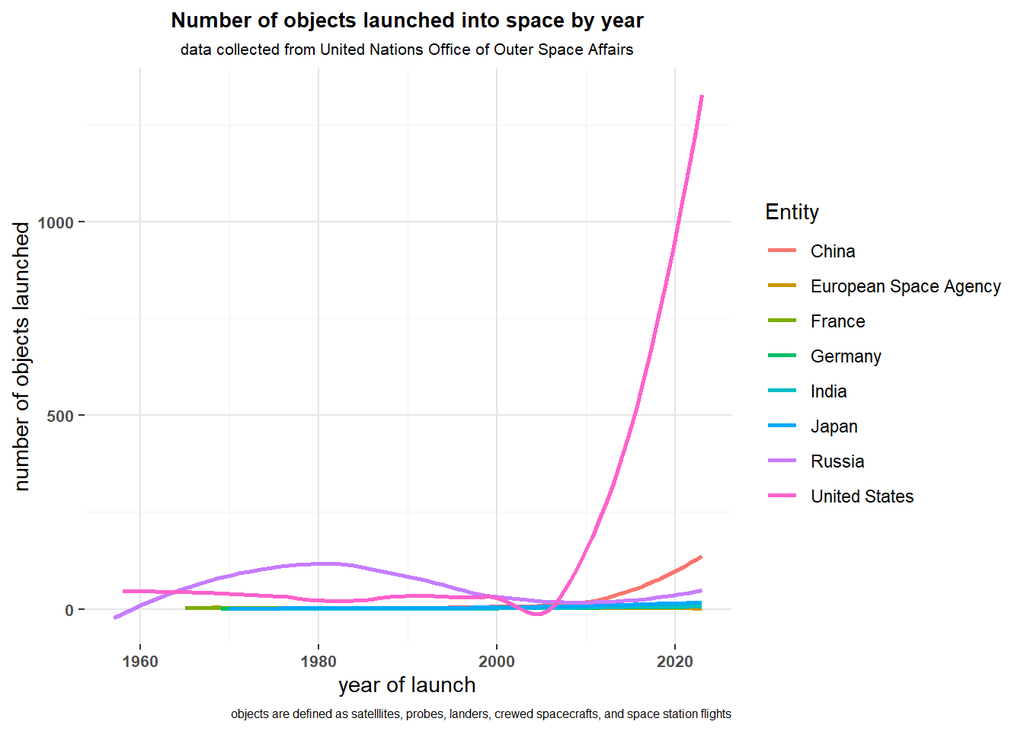

```r
ggplot(data = filtered_outer_space_objects, aes(x=Year, y=num_objects, color = Entity)) +
  geom_smooth(se = FALSE, method = loess) +
  labs(
    x = "year of launch",
    y = "number of objects launched",
    title = "Number of objects launched into space by year",
    subtitle = "data collected from United Nations Office of Outer Space Affairs",
    caption = "objects are defined as satelllites, probes, landers, crewed spacecrafts, and space station flights"
  ) +
  theme(
    axis.text.x = element_text(size = 8, face = "bold"),
    axis.text.y = element_text(size = 8, face = "bold"),
    plot.title = element_text (size = 10, face = "bold", hjust = 0.5),
    plot.subtitle = element_text(size = 8, face = "plain", hjust = 0.5),
    plot.caption = element_text(size = 6, face = "plain", hjust = 1),
    panel.background = element_rect(fill = "white"),
    plot.background = element_rect(fill = "white"),
    panel.grid.major = element_line(color = "gray90"),
    panel.grid.minor = element_line(color = "gray95")
  )
```

## Questions

- Question 1 - what country is most likely to become the first “space faring nation” and is there a close second? I propose to define “space faring nation” as the country that launches an order of magnitude more vehicles into space than all other countries combined. I’ll fit a polynomial regression model to the dataset by country and extrapolate the model into the future to help identify the likely candidates.

## Analysis plan

- The analysis plan is to plot the data on a map and display the launches by country over time. Currently, I have no idea how to do this, create a map, and plot an event from the data set onto the map?
- I am thinking I will need to get a map of the world with the countries displayed. Another data set with the longitude and latitude for each country may be needed.
- The launch event data set includes country and number of launches per year, to this I am thinking I will need to add columns defining the longitude and latitude of each launch event.
- With longitude and latitude defined for each row/event I would then plot the launches on a map.
- The analysis plan is to have an office hours meetign with Professor Chism the week of June 3rd and discuss how to plot country launch data on a world map. I’ll then completed the required learning and apply that new skillset to the launch dataset.

## Plan of Attack

Approach by Task

| Task Name | Status | Date | Summary |
| --- | --- | --- | --- |
| Select dataset | complete | May 27th | selected the Space Object Launch Dataset |
| Define question to be answered | complete | May 28th | what country is most likely to become the 1st space faring nation |
| Submit draft proposal for peer review | complete | May 29th | proposal submitted - comments under review |
| Response to peer review | complete | June 2nd | peer review comments incorporate into the proposal |
| Submit project proposal | complete | June 3rd | proposal submitted to Professor Chism |
| Office hours with Prof Chism to discuss approach | in-work | June 9th | need to learn how to plot launch data on a map? |
| Complete required learning | in-work | June 15th | Reviewed material suggested by Prof. Chism |
| Complete initial analysis of the dataset | not started | June 15th | Data plotted on a map |
| draft presentation and writeup | not started | June 21st | draft files committed to github |
| Complete presentation | not started | June 23rd | submit to github |
| Comlete writeup | not started | June 23rd | submit to github |
| final submission | not started | June 24th | submit to github |